# Webinar 1 - R for Data Management

Frank Namugera (PhD)

2026-08-27

# 1 Introduction

This R Markdown file is the **live-coding companion** to Webinar 1. It follows the session agenda below and uses a real **Malawi Demographic and Health Survey (MDHS)** Individual Recode (women’s) file throughout, so every function is demonstrated on genuine survey data rather than a toy example.

## 1.1 Session Setup

### 1.1.1 1. Install R

Download R from:

https://cran.r-project.org/

Steps: - Select your operating system (Windows/macOS/Linux). - Download and install the latest version. - Accept the default installation settings.

### 1.1.2 2. Install RStudio

Download RStudio Desktop from:

https://posit.co/download/rstudio-desktop/

Steps: - Install RStudio after installing R. - Open RStudio and confirm that R is detected.

## 1.2 Research Focus

**Determinants of Modern Contraceptive Use among Women Aged 15–49 Years**

Modern contraceptive use is a key indicator of reproductive health and is essential for reducing unintended pregnancies, improving maternal and child health outcomes, and supporting sustainable population growth. Using data from the Malawi DHS, this session examines the determinants of modern contraceptive use among women aged 15–49, and how it varies by age, education, marital status, wealth, place of residence, region, employment, media exposure, and number of living children.

If you have downloaded your own DHS extract (`.dta` or `.sav`) from the [DHS Program website](https://dhsprogram.com/data/available-datasets.cfm), point `file_path` in the import step below to it.

**Tip:** DHS data requires free registration and project approval before download – start that process early if you plan to use your own country’s data.

# 2 R & RStudio Basics

## 2.1 How R Works

R has a set of methods and functions designed and packaged into libraries. For every programming task, you need to know the appropriate functions and packages to install and use; where a ready-made function doesn’t exist, you can write your own (a “user-defined function”).

RStudio is the IDE used to manage your datasets, scripts, and visualizations in one place.

## 2.2 Creating and Managing an R Project

### 2.2.1 Step 1: Create a New Project

- Open **RStudio**
- Go to **File -> New Project**
- Select **New Directory -> New Project**
- Enter a project name and choose a location
- Click **Create Project**

### 2.2.2 Step 2: Organize Your Project

Create folders to keep your work organized:

```
Project_Name/
|
|-- data/
|-- scripts/
|-- figures/
|-- output/
|-- reports/
`-- Project_Name.Rproj
```

## 2.3 Good Practices

- Use one project per analysis
- Organize files into folders
- Use relative file paths instead of hard-coded `setwd()` calls
- Save your work regularly
- Keep raw and cleaned data separate

## 2.4 Basic R Operations

R can handle everything from simple arithmetic to full statistical models. We will build up to the DHS analysis gradually, starting with the basics:

```r
## the assignment operator
a <- 2
b <- 5:10
c <- c("a", "b", "d")
```

## 2.5 Loading Required Packages

```r
# install.packages(c("tidyverse", "haven", "readxl", "labelled"))

library(tidyverse)   # dplyr, ggplot2, tidyr, stringr, etc.
library(haven)       # read Stata (.dta) / SPSS (.sav) files -- standard DHS formats
library(readxl)      # read Excel files
library(labelled)    # helper functions for labelled survey data

# library(tidyverse) # ctr+enter
```

```r
# Check and, if needed, set your working directory
# getwd()
# # setwd("path/to/your/project")
#
# setwd()
```

# 3 Importing and Inspecting Data

## 3.1 Built in datasets

R comes with several datasets under the different libraries. Sometimes the research questions could be answered by some of these datasets.

```r
# This functions shows you all available datasets under the base function

# data()
# ChickWeight
```

## 3.2 Supported Data Formats

R can read data from many formats, including `.csv`, `.xlsx`, `.sav`, `.dta`, `.R`/`.RData`, and more. This session focuses on `.dta` (Stata format), since that is how the Malawi DHS Individual Recode file is distributed.

## 3.3 Importing the DHS Dataset

```r
# Update this path to point to your own DHS extract
# change these paths to make reference to the directory that has the dataset.
file_path_dta <- "C:/Users/FRANK/Desktop/R training/DHS_data.dta"
file_path_csv<- "C:/Users/FRANK/Desktop/R training/DHS_data.csv"

dhs_data <- read_dta(file_path_dta) # haven: read_dta
dhs_data<- mutate(dhs_data, across(where(is.labelled), as_factor))

## piping function |>

dhs_data <- read_dta(file_path_dta) |>
  mutate(across(where(is.labelled), as_factor))  ### haven and convert values to value labels.
```

## 3.4 saving datasets

Likewise, several formats can be save from R

```r
# in csv:
# write.csv(dhs_data, "filename.csv")
#
# # stata
# write_dta(dhs_data, "filename.dta")
#
# # spss
#
# write_sav(dhs_data, "filename.sav")

# etc
```

## 3.5 Selecting Variables of Interest

```r
var_names <- c(
  "caseid", # case id
  "v005",   # sampling weight
  "v021",   # primary sampling unit (cluster)
  "v022",   # sampling strata

  "v024",   # region
  "v025",   # place of residence
  "v012",   # age
  "v106",   # highest education level
  "v130",   # religion
  "v190",   # wealth index
  "v201",   # children ever born
  "v218",   # number of living children
  "v213",   # currently pregnant
  "v312",   # current contraceptive method
  "v313",   # current contraceptive method type
  "v501",   # marital status
  "v714",   # currently working
  "v717",   # respondent's occupation
  "v701",   # husband's education
  "v705",   # husband's occupation
  "v157",   # reads newspaper
  "v158",   # listens to radio
  "v159",   # watches television
  "v394",   # visited health facility
  "v481"    # health insurance coverage
  )

dhs_raw <- dhs_data |> select(var_names)

# dhs_data|> select(v024, v025, v394) |>View()

# other aproaches such as dhs_data[c(var_names)]
```

## 3.6 First Look at the Data

```r
# View(dhs_raw)

dim(dhs_raw)
```

```
## [1] 24662    25
```

```r
nrow(dhs_raw);
```

```
## [1] 24662
```

```r
ncol(dhs_raw)
```

```
## [1] 25
```

```r
# overview
head(dhs_raw, n = 10)
```

```
## # A tibble: 10 × 25
##    caseid       v005  v021 v022  v024  v025   v012 v106  v130  v190   v201  v218
##    <chr>       <dbl> <dbl> <fct> <fct> <fct> <dbl> <fct> <fct> <fct> <dbl> <dbl>
##  1 "       1… 118748     1 ntch… cent… urban    30 seco… ccap  rich…     3     2
##  2 "       1… 118748     1 ntch… cent… urban    30 prim… ccap  rich…     4     4
##  3 "       1… 118748     1 ntch… cent… urban    28 prim… othe… rich…     3     3
##  4 "       1… 118748     1 ntch… cent… urban    30 seco… cath… rich…     1     1
##  5 "       1… 118748     1 ntch… cent… urban    16 seco… othe… rich…     0     0
##  6 "       1… 118748     1 ntch… cent… urban    36 seco… othe… midd…     3     3
##  7 "       1… 118748     1 ntch… cent… urban    24 seco… ccap  rich…     2     2
##  8 "       1… 118748     1 ntch… cent… urban    23 seco… ccap  rich…     1     1
##  9 "       1… 118748     1 ntch… cent… urban    28 seco… othe… rich…     4     4
## 10 "       1… 118748     1 ntch… cent… urban    29 seco… ccap  rich…     0     0
## # ℹ 13 more variables: v213 <fct>, v312 <fct>, v313 <fct>, v501 <fct>,
## #   v714 <fct>, v717 <fct>, v701 <fct>, v705 <fct>, v157 <fct>, v158 <fct>,
## #   v159 <fct>, v394 <fct>, v481 <fct>
```

```r
tail(dhs_raw, n = 5)
```

```
## # A tibble: 5 × 25
##   caseid        v005  v021 v022  v024  v025   v012 v106  v130  v190   v201  v218
##   <chr>        <dbl> <dbl> <fct> <fct> <fct> <dbl> <fct> <fct> <fct> <dbl> <dbl>
## 1 "     483 … 1.37e5   483 phal… sout… urban    29 high… othe… rich…     1     0
## 2 "     409 … 5.19e5   409 nkho… cent… rural    15 prim… othe… poor…     0     0
## 3 "     273 … 1.21e6   273 blan… sout… rural    34 seco… musl… midd…     3     3
## 4 "     493 … 1.01e6   493 mchi… cent… rural    17 prim… cath… poor…     1     1
## 5 "     499 … 2.39e6   499 mzim… nort… rural    43 prim… cath… rich…     4     4
## # ℹ 13 more variables: v213 <fct>, v312 <fct>, v313 <fct>, v501 <fct>,
## #   v714 <fct>, v717 <fct>, v701 <fct>, v705 <fct>, v157 <fct>, v158 <fct>,
## #   v159 <fct>, v394 <fct>, v481 <fct>
```

```r
names(dhs_raw)
```

```
##  [1] "caseid" "v005"   "v021"   "v022"   "v024"   "v025"   "v012"   "v106"
##  [9] "v130"   "v190"   "v201"   "v218"   "v213"   "v312"   "v313"   "v501"
## [17] "v714"   "v717"   "v701"   "v705"   "v157"   "v158"   "v159"   "v394"
## [25] "v481"
```

```r
## data types
str(dhs_raw)
```

```
## tibble [24,662 × 25] (S3: tbl_df/tbl/data.frame)
##  $ caseid: chr [1:24662] "       1  12  2" "       1  17  2" "       1  39  2" "       1  66  2" ...
##   ..- attr(*, "label")= chr "case identification"
##   ..- attr(*, "format.stata")= chr "%-9s"
##  $ v005  : num [1:24662] 118748 118748 118748 118748 118748 ...
##   ..- attr(*, "label")= chr "women's individual sample weight (6 decimals)"
##   ..- attr(*, "format.stata")= chr "%10.0g"
##  $ v021  : num [1:24662] 1 1 1 1 1 1 1 1 1 1 ...
##   ..- attr(*, "label")= chr "primary sampling unit"
##   ..- attr(*, "format.stata")= chr "%10.0g"
##  $ v022  : Factor w/ 56 levels "chitipa - rural",..: 18 18 18 18 18 18 18 18 18 18 ...
##   ..- attr(*, "label")= chr "sample strata for sampling errors"
##  $ v024  : Factor w/ 3 levels "northern region",..: 2 2 2 2 2 2 2 2 2 2 ...
##   ..- attr(*, "label")= chr "region"
##  $ v025  : Factor w/ 2 levels "urban","rural": 1 1 1 1 1 1 1 1 1 1 ...
##   ..- attr(*, "label")= chr "type of place of residence"
##  $ v012  : num [1:24662] 30 30 28 30 16 36 24 23 28 29 ...
##   ..- attr(*, "label")= chr "respondent's current age"
##   ..- attr(*, "format.stata")= chr "%10.0g"
##  $ v106  : Factor w/ 4 levels "no education",..: 3 2 2 3 3 3 3 3 3 3 ...
##   ..- attr(*, "label")= chr "highest educational level"
##  $ v130  : Factor w/ 8 levels "catholic","ccap",..: 2 2 5 1 5 5 2 2 5 2 ...
##   ..- attr(*, "label")= chr "religion"
##  $ v190  : Factor w/ 5 levels "poorest","poorer",..: 5 5 5 4 4 3 5 5 5 5 ...
##   ..- attr(*, "label")= chr "wealth index combined"
##  $ v201  : num [1:24662] 3 4 3 1 0 3 2 1 4 0 ...
##   ..- attr(*, "label")= chr "total children ever born"
##   ..- attr(*, "format.stata")= chr "%10.0g"
##  $ v218  : num [1:24662] 2 4 3 1 0 3 2 1 4 0 ...
##   ..- attr(*, "label")= chr "number of living children"
##   ..- attr(*, "format.stata")= chr "%10.0g"
##  $ v213  : Factor w/ 2 levels "no or unsure",..: 1 1 1 1 1 1 2 1 1 1 ...
##   ..- attr(*, "label")= chr "currently pregnant"
##  $ v312  : Factor w/ 21 levels "not using","pill",..: 1 12 12 4 1 1 1 12 4 1 ...
##   ..- attr(*, "label")= chr "current contraceptive method"
##  $ v313  : Factor w/ 4 levels "no method","folkloric method",..: 1 4 4 4 1 1 1 4 4 1 ...
##   ..- attr(*, "label")= chr "current use by method type"
##  $ v501  : Factor w/ 6 levels "never in union",..: 2 2 2 4 1 6 2 2 2 1 ...
##   ..- attr(*, "label")= chr "current marital status"
##  $ v714  : Factor w/ 2 levels "no","yes": 1 2 1 2 1 2 1 2 1 2 ...
##   ..- attr(*, "label")= chr "respondent currently working"
##  $ v717  : Factor w/ 11 levels "not working",..: 1 5 1 5 1 2 1 10 1 2 ...
##   ..- attr(*, "label")= chr "respondent's occupation (grouped)"
##  $ v701  : Factor w/ 5 levels "no education",..: 4 3 3 NA NA NA 3 3 3 NA ...
##   ..- attr(*, "label")= chr "husband/partner's education level"
##  $ v705  : Factor w/ 11 levels "did not work",..: 2 2 2 NA NA NA 10 2 2 NA ...
##   ..- attr(*, "label")= chr "husband/partner's occupation (grouped)"
##  $ v157  : Factor w/ 4 levels "not at all","less than once a week",..: 3 1 1 2 1 2 2 1 1 1 ...
##   ..- attr(*, "label")= chr "frequency of reading newspaper or magazine"
##  $ v158  : Factor w/ 4 levels "not at all","less than once a week",..: 3 3 1 2 1 2 3 3 3 2 ...
##   ..- attr(*, "label")= chr "frequency of listening to radio"
##  $ v159  : Factor w/ 4 levels "not at all","less than once a week",..: 3 3 1 2 1 1 2 3 1 2 ...
##   ..- attr(*, "label")= chr "frequency of watching television"
##  $ v394  : Factor w/ 2 levels "no","yes": 2 2 2 2 2 2 1 2 2 2 ...
##   ..- attr(*, "label")= chr "visited health facility last 12 months"
##  $ v481  : Factor w/ 2 levels "no","yes": 2 1 1 1 1 1 1 1 1 1 ...
##   ..- attr(*, "label")= chr "covered by health insurance"
```

```r
glimpse(dhs_raw)
```

```
## Rows: 24,662
## Columns: 25
## $ caseid <chr> "       1  12  2", "       1  17  2", "       1  39  2", "     …
## $ v005   <dbl> 118748, 118748, 118748, 118748, 118748, 118748, 118748, 118748,…
## $ v021   <dbl> 1, 1, 1, 1, 1, 1, 1, 1, 1, 1, 1, 1, 1, 1, 1, 1, 1, 1, 1, 1, 1, …
## $ v022   <fct> ntchisi - urban, ntchisi - urban, ntchisi - urban, ntchisi - ur…
## $ v024   <fct> central region, central region, central region, central region,…
## $ v025   <fct> urban, urban, urban, urban, urban, urban, urban, urban, urban, …
## $ v012   <dbl> 30, 30, 28, 30, 16, 36, 24, 23, 28, 29, 22, 33, 26, 29, 15, 26,…
## $ v106   <fct> secondary, primary, primary, secondary, secondary, secondary, s…
## $ v130   <fct> ccap, ccap, other christian, catholic, other christian, other c…
## $ v190   <fct> richest, richest, richest, richer, richer, middle, richest, ric…
## $ v201   <dbl> 3, 4, 3, 1, 0, 3, 2, 1, 4, 0, 2, 3, 2, 4, 0, 2, 1, 1, 2, 0, 0, …
## $ v218   <dbl> 2, 4, 3, 1, 0, 3, 2, 1, 4, 0, 1, 3, 2, 4, 0, 2, 1, 1, 2, 0, 0, …
## $ v213   <fct> no or unsure, no or unsure, no or unsure, no or unsure, no or u…
## $ v312   <fct> not using, implants/norplant, implants/norplant, injections, no…
## $ v313   <fct> no method, modern method, modern method, modern method, no meth…
## $ v501   <fct> married, married, married, widowed, never in union, no longer l…
## $ v714   <fct> no, yes, no, yes, no, yes, no, yes, no, yes, yes, yes, no, no, …
## $ v717   <fct> not working, agricultural - self employed, not working, agricul…
## $ v701   <fct> higher, secondary, secondary, NA, NA, NA, secondary, secondary,…
## $ v705   <fct> professional/technical/managerial, professional/technical/manag…
## $ v157   <fct> at least once a week, not at all, not at all, less than once a …
## $ v158   <fct> at least once a week, at least once a week, not at all, less th…
## $ v159   <fct> at least once a week, at least once a week, not at all, less th…
## $ v394   <fct> yes, yes, yes, yes, yes, yes, no, yes, yes, yes, yes, yes, no, …
## $ v481   <fct> yes, no, no, no, no, no, no, no, no, no, no, no, no, no, no, no…
```

```r
## data summary/descriptives
summary(dhs_raw)
```

```
##     caseid               v005              v021                     v022
##  Length:24662       Min.   :  12778   Min.   :  1.0   mangochi - rural:  863
##  Class :character   1st Qu.: 428519   1st Qu.:215.0   thyolo - rural  :  830
##  Mode  :character   Median : 854425   Median :425.0   dedza - rural   :  826
##                     Mean   :1000052   Mean   :425.4   dowa - rural    :  820
##                     3rd Qu.:1289055   3rd Qu.:635.0   ntcheu - rural  :  807
##                     Max.   :6400914   Max.   :850.0   phalombe - rural:  807
##                                                       (Other)         :19709
##               v024          v025            v012                 v106
##  northern region: 4829   urban: 5267   Min.   :15.00   no education: 2786
##  central region : 8454   rural:19395   1st Qu.:20.00   primary     :15090
##  southern region:11379                 Median :27.00   secondary   : 6085
##                                        Mean   :28.13   higher      :  701
##                                        3rd Qu.:35.00
##                                        Max.   :49.00
##
##                               v130            v190           v201
##  other christian                :10436   poorest:4295   Min.   : 0.000
##  catholic                       : 4337   poorer :4445   1st Qu.: 1.000
##  ccap                           : 3894   middle :4530   Median : 2.000
##  muslim                         : 2739   richer :4916   Mean   : 2.769
##  seventh day adventist / baptist: 1843   richest:6476   3rd Qu.: 4.000
##  anglican                       : 1262                  Max.   :15.000
##  (Other)                        :  151
##       v218                  v213                         v312
##  Min.   : 0.000   no or unsure:22822   not using           :13426
##  1st Qu.: 1.000   yes         : 1840   injections          : 5445
##  Median : 2.000                        implants/norplant   : 2328
##  Mean   : 2.475                        female sterilization: 1900
##  3rd Qu.: 4.000                        male condom         :  679
##  Max.   :11.000                        pill                :  421
##                                        (Other)             :  463
##                  v313                                        v501
##  no method         :13426   never in union                     : 5351
##  folkloric method  :   53   married                            :14977
##  traditional method:  153   living with partner                : 1041
##  modern method     :11030   widowed                            :  743
##                             divorced                           : 1240
##                             no longer living together/separated: 1310
##
```

[output cut: 17 more lines]

```
##  not at all           :12365   not at all           :19144   no : 9440
##  less than once a week: 4248   less than once a week: 2117   yes:15222
##  at least once a week : 8049   at least once a week : 3401
##  almost every day     :    0   almost every day     :    0
##
##
##
##   v481
##  no :24325
##  yes:  337
##
##
##
##
##
```

```r
summary(dhs_raw |> select(v025, v106))
```

```
##     v025                 v106
##  urban: 5267   no education: 2786
##  rural:19395   primary     :15090
##                secondary   : 6085
##                higher      :  701
```

# 4 Data Cleaning – Part 1

## 4.1 Objectives

By the end of this segment, participants should be able to:

- Rename variables
- Identify and handle missing values
- Detect and remove duplicate records
- Recode variables
- Work with categorical variables
- Detect and handle outliers

## 4.2 Renaming Variables

DHS datasets use standardized variable names (e.g., `v012`, `v106`). Renaming them up front makes every subsequent step easier to read.

```r
names(dhs_raw)
```

```
##  [1] "caseid" "v005"   "v021"   "v022"   "v024"   "v025"   "v012"   "v106"
##  [9] "v130"   "v190"   "v201"   "v218"   "v213"   "v312"   "v313"   "v501"
## [17] "v714"   "v717"   "v701"   "v705"   "v157"   "v158"   "v159"   "v394"
## [25] "v481"
```

```r
# shortcut for %>%  is ctr+shift+m %>%
# dhs_raw$age<- dhs_raw$v012


dhs <- dhs_raw |>
  rename(
    age                     = v012,
    region                  = v024,
    residence               = v025,
    education               = v106,
    religion                = v130,
    wealth_quintile         = v190,
    children_ever_born      = v201,
    pregnant                = v213,
    living_children         = v218,
    contraceptive           = v313,
    marital_status          = v501,
    currently_working       = v714,
    occupation              = v717,
    husband_education       = v701,
    husband_occupation      = v705,
    reads_newspaper         = v157,
    listens_radio           = v158,
    watches_tv              = v159,
    visited_health_facility = v394,
    health_insurance        = v481
  )

names(dhs)
```

```
##  [1] "caseid"                  "v005"
##  [3] "v021"                    "v022"
##  [5] "region"                  "residence"
##  [7] "age"                     "education"
##  [9] "religion"                "wealth_quintile"
## [11] "children_ever_born"      "living_children"
## [13] "pregnant"                "v312"
## [15] "contraceptive"           "marital_status"
## [17] "currently_working"       "occupation"
## [19] "husband_education"       "husband_occupation"
## [21] "reads_newspaper"         "listens_radio"
## [23] "watches_tv"              "visited_health_facility"
## [25] "health_insurance"
```

## 4.3 Identifying Missing Values

```r
# Count missing values for every column

# anyNA()

# is.na(dhs$marital_status)

# in a single variable:
sum(is.na(dhs$marital_status))
```

```
## [1] 0
```

```r
###
# is.na(dhs)

## overall:
# colSums(is.na(dhs))
```

## 4.4 Handling Missing Values

DHS commonly uses special numeric codes for “missing” instead of a blank cell. We convert these to proper `NA` so R treats them correctly.

```r
colSums(is.na(dhs))
```

```
##                  caseid                    v005                    v021
##                       0                       0                       0
##                    v022                  region               residence
##                       0                       0                       0
##                     age               education                religion
##                       0                       0                       0
##         wealth_quintile      children_ever_born         living_children
##                       0                       0                       0
##                pregnant                    v312           contraceptive
##                       0                       0                       0
##          marital_status       currently_working              occupation
##                       0                       0                       0
##       husband_education      husband_occupation         reads_newspaper
##                    8644                    8644                       0
##           listens_radio              watches_tv visited_health_facility
##                       0                       0                       0
##        health_insurance
##                       0
```

```r
# Let's check the husband_education & husband_occupation
# subset()

# dhs %>% filter(is.na(husband_education)) |> dim()

### sometimes missingness is a design intent not an error. What can you seen in common in all these women?

# dhs %>% filter(is.na(husband_education)) |> view()

# Muted since there are no missing ness.
# dhs <- dhs |>
#   mutate(
#     age             = na_if(age, 98),
#     education       = na_if(education, 9),
#     pregnant        = na_if(pregnant, 9),
#     living_children = na_if(living_children, 99)
#   )
```

## 4.5 Removing Duplicate Records

Duplicate records can give a misleading picture of the data by over-weighting a small number of respondents.

```r
# How many caseids appear more than once?
## use the duplicated() function

sum(duplicated(dhs$caseid))
```

```
## [1] 100
```

```r
# Inspect the duplicated rows themselves (both occurrences)
dhs_duplicates <- dhs |>
  filter(duplicated(caseid) | duplicated(caseid, fromLast = TRUE))


dim(dhs_duplicates)
```

```
## [1] 200  25
```

```r
dhs_duplicates
```

```
## # A tibble: 200 × 25
##    caseid             v005  v021 v022  region residence   age education religion
##    <chr>             <dbl> <dbl> <fct> <fct>  <fct>     <dbl> <fct>     <fct>
##  1 "       6  97  … 2.01e6     6 mzim… north… rural        35 primary   other c…
##  2 "      23  42  … 6.93e5    23 mang… south… rural        21 secondary other c…
##  3 "      27 159  … 4.91e5    27 rump… north… rural        31 primary   catholic
##  4 "      27 196  … 4.91e5    27 rump… north… rural        34 primary   other c…
##  5 "      33  42  … 1.04e6    33 dowa… centr… rural        19 primary   ccap
##  6 "      37   3  … 8.20e5    37 mzim… north… urban        29 secondary catholic
##  7 "      38  10  … 2.31e5    38 mchi… centr… urban        22 primary   other c…
##  8 "      40 100  … 3.34e5    40 nkha… north… rural        40 secondary ccap
##  9 "      64 209  … 1.50e6    64 zomb… south… rural        15 primary   muslim
## 10 "      83  49  … 2.70e5    83 neno… south… rural        22 secondary catholic
## # ℹ 190 more rows
## # ℹ 16 more variables: wealth_quintile <fct>, children_ever_born <dbl>,
## #   living_children <dbl>, pregnant <fct>, v312 <fct>, contraceptive <fct>,
## #   marital_status <fct>, currently_working <fct>, occupation <fct>,
## #   husband_education <fct>, husband_occupation <fct>, reads_newspaper <fct>,
## #   listens_radio <fct>, watches_tv <fct>, visited_health_facility <fct>,
## #   health_insurance <fct>
```

```r
# Keep only one unique occurrence of each caseid

dhs <- dhs |> distinct(caseid, .keep_all = TRUE)
nrow(dhs)
```

```
## [1] 24562
```

## 4.6 Recoding Variables

`residence` and `education` are already value-labelled by DHS, so we don’t need to manually retype their coding scheme – that comes in the next section via `as_factor()`. The one variable that genuinely needs manual recoding here is `age_group`, since it’s a brand-new category that doesn’t exist as a raw DHS variable and so has no label to inherit:

```r
dhs <- dhs |>
  mutate(
    age_group = case_when(
      age >= 15 & age < 20  ~ "15-19",
      age >= 20 & age < 35  ~ "20-34",
      age >= 35 & age <= 49 ~ "35-49",
      TRUE ~ NA_character_
    )

    # An equivalent (but harder to read for 3+ categories) version with
    # nested ifelse() would be:
    # age_group = ifelse(age >= 15 & age < 20, "15-19",
    #             ifelse(age >= 20 & age < 35, "20-34",
    #             ifelse(age >= 35 & age <= 49, "35-49", NA)))
  )

count(dhs, age_group)
```

```
## # A tibble: 3 × 2
##   age_group     n
##   <chr>     <int>
## 1 15-19      5273
## 2 20-34     12718
## 3 35-49      6571
```

## 4.7 Working with Categorical Variables (Factors)

Because `residence` and `education` are already value-labelled, `as_factor()` pulls in DHS’s own text labels directly, no manual mapping required, and no risk of a typo creating a mismatched category:

```r
dhs <- dhs |>
  mutate(
    residence_f = as_factor(residence),
    education_f = factor(as_factor(education), ordered = TRUE),
    age_group_f = factor(age_group, levels = c("15-19", "20-34", "35-49"))
  )

levels(dhs$residence_f)
```

```
## [1] "urban" "rural"
```

```r
levels(dhs$education_f)
```

```
## [1] "no education" "primary"      "secondary"    "higher"
```

```r
table(dhs$education_f, useNA = "ifany")
```

```
##
## no education      primary    secondary       higher
##         2779        15028         6061          694
```

`as_factor()` gives us the categories DHS already defined. Manual recoding still earns its keep when you want *different* groupings than the source labels provide – for example, collapsing four education levels down to two for a simpler comparison:

```r
dhs <- dhs |>
  mutate(
    education_grouped = fct_collapse(
      education_f,
      "no education"      = "no education",
      "Primary or higher" = c("primary", "secondary", "higher")
    )
  )

table(dhs$education_grouped)
```

```
##
##      no education Primary or higher
##              2779             21783
```

## 4.8 Outlier Detection and Removal

Outliers are values that fall far outside a variable’s typical range. Left unaddressed, they can distort means, standard deviations, and any models built on the data. Two complementary checks are useful:

1. **Validity / range checks**: for variables with a known plausible range. This survey only interviews women aged 15–49, so any value outside that range is a data error, not a genuine outlier.
2. **Statistical outlier detection**: for continuous variables without a fixed valid range (e.g., number of living children), where a rule such as the interquartile range (IQR) flags unusually extreme values.

### 4.8.1 Validity check: age

```r
# This should return 0 rows if age was recorded correctly
dhs %>% filter(age < 15 | age > 49)
```

```
## # A tibble: 0 × 30
## # ℹ 30 variables: caseid <chr>, v005 <dbl>, v021 <dbl>, v022 <fct>,
## #   region <fct>, residence <fct>, age <dbl>, education <fct>, religion <fct>,
## #   wealth_quintile <fct>, children_ever_born <dbl>, living_children <dbl>,
## #   pregnant <fct>, v312 <fct>, contraceptive <fct>, marital_status <fct>,
## #   currently_working <fct>, occupation <fct>, husband_education <fct>,
## #   husband_occupation <fct>, reads_newspaper <fct>, listens_radio <fct>,
## #   watches_tv <fct>, visited_health_facility <fct>, health_insurance <fct>, …
```

### 4.8.2 Statistical outlier detection: living children

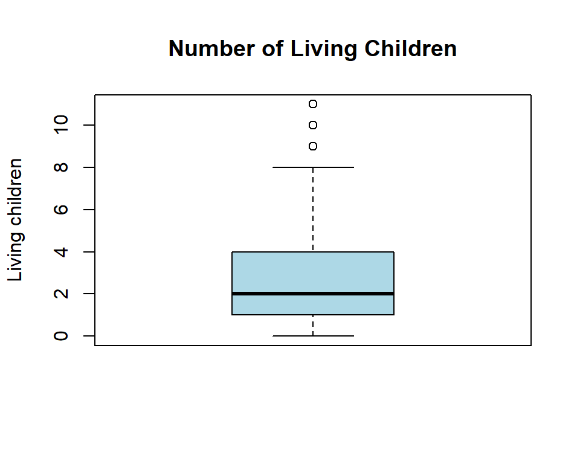

```r
# dhs$living_children

boxplot(dhs$living_children,
        main = "Number of Living Children",
        ylab = "Living children",
        col  = "lightblue")
```

```r
Q1      <- quantile(dhs$living_children, 0.25, na.rm = TRUE)
Q3      <- quantile(dhs$living_children, 0.75, na.rm = TRUE)
IQR_val <- IQR(dhs$living_children, na.rm = TRUE)

lower_bound <- Q1 - 1.5 * IQR_val
upper_bound <- Q3 + 1.5 * IQR_val

c(lower_bound = lower_bound, upper_bound = upper_bound)
```

```
## lower_bound.25% upper_bound.75%
##            -3.5             8.5
```

```r
# How many observations fall outside these bounds?

dhs %>%
  filter(living_children < lower_bound | living_children > upper_bound) %>%
  nrow()
```

```
## [1] 159
```

```r
# Flag outliers rather than silently deleting them, so the decision stays
# auditable
dhs <- dhs |>
  mutate(
    living_children_outlier = living_children < lower_bound |
                               living_children > upper_bound
  )

# table()

table(dhs$living_children_outlier, useNA = "ifany")
```

```
##
## FALSE  TRUE
## 24403   159
```

```r
# Remove confirmed outliers (missing values were already handled earlier,
# so we keep NAs rather than dropping them here)
dhs <- dhs |>
  filter(is.na(living_children) | !living_children_outlier)
```

> **Note:** removing outliers is not always the right choice – a woman may genuinely have an unusually high number of children. Always inspect flagged cases before deleting them, and document the rule you used.

# 5 Data Cleaning – Part 2

## 5.1 Objectives

Participants should be able to:

- Create new variables using `mutate()`
- Select variables using `select()`
- Filter observations using `filter()`
- Arrange data using `arrange()`
- Combine cleaning steps into a single pipeline

## 5.2 Creating New Variables with `mutate()`

The DHS variable `contraceptive` (originally `v313`) classifies contraceptive methods as:

| Code | Method Type |
| --- | --- |
| 0 | No method |
| 1 | Folkloric |
| 2 | Traditional |
| 3 | Modern |

```r
dhs <- dhs |>
  mutate(modern_use = ifelse(contraceptive == "modern method", "yes", "no"))

head(dhs$modern_use)
```

```
## [1] "no"  "yes" "yes" "yes" "no"  "no"
```

We also create a media exposure indicator for women exposed to at least one media source:

```r
# and &
# a OR b -   |

# a==b
# a!=b

dhs <- dhs |>
  mutate(
    media_exposure = ifelse(
      reads_newspaper != "not at all"  | listens_radio != "not at all" | watches_tv != "not at all",
      "Yes", "No"
    )
  )

table(dhs$media_exposure, useNA = "ifany")
```

```
##
##    No   Yes
## 10492 13911
```

## 5.3 Selecting Variables with `select()`

General syntax:

```r
data |> select(variable1, variable2)
```

**Select a few variables to preview:**

```r
dhs |>
  select(age, education_f, residence_f, modern_use) %>%
  head()
```

```
## # A tibble: 6 × 4
##     age education_f residence_f modern_use
##   <dbl> <ord>       <fct>       <chr>
## 1    30 secondary   urban       no
## 2    30 primary     urban       yes
## 3    28 primary     urban       yes
## 4    30 secondary   urban       yes
## 5    16 secondary   urban       no
## 6    36 secondary   urban       no
```

**Remove variables you no longer need** (e.g., the individual media items, once `media_exposure` has been derived from them):

```r
dhs %>%
  select(-reads_newspaper, -listens_radio, -watches_tv) %>%
  names()
```

```
##  [1] "caseid"                  "v005"
##  [3] "v021"                    "v022"
##  [5] "region"                  "residence"
##  [7] "age"                     "education"
##  [9] "religion"                "wealth_quintile"
## [11] "children_ever_born"      "living_children"
## [13] "pregnant"                "v312"
## [15] "contraceptive"           "marital_status"
## [17] "currently_working"       "occupation"
## [19] "husband_education"       "husband_occupation"
## [21] "visited_health_facility" "health_insurance"
## [23] "age_group"               "residence_f"
## [25] "education_f"             "age_group_f"
## [27] "education_grouped"       "living_children_outlier"
## [29] "modern_use"              "media_exposure"
```

**Select by name pattern** – most useful *before* renaming, directly on the raw DHS codes:

```r
# Variables starting with "v1"
dhs_raw %>% select(starts_with("v1")) %>% names()
```

```
## [1] "v106" "v130" "v190" "v157" "v158" "v159"
```

```r
# Variables ending in "01"
dhs_raw %>% select(ends_with("01")) %>% names()
```

```
## [1] "v201" "v501" "v701"
```

```r
# contains()
```

## 5.4 Filtering Observations with `filter()`

General syntax:

```r
data %>% filter(condition)
```

```r
# Women aged 15-49
women_15_49 <- dhs %>% filter(age >= 15 & age <= 49)

# Rural women
rural <- dhs %>% filter(residence == "rural")

# Urban women
urban <- dhs %>% filter(residence == "urban")

# Married women
married <- dhs %>% filter(marital_status == "married")

# Women using a modern contraceptive method
users <- dhs %>% filter(modern_use == "yes")

# Multiple conditions at once: rural, secondary+ education, modern users
subset_data <- dhs %>%
  filter(residence == 'ubarn', education %in%  c("secondary", "higher"), modern_use == "yes")

nrow(women_15_49); nrow(rural); nrow(urban); nrow(married); nrow(users); nrow(subset_data)
```

```
## [1] 24403
```

```
## [1] 19160
```

```
## [1] 5243
```

```
## [1] 14783
```

```
## [1] 10920
```

```
## [1] 0
```

## 5.5 Arranging Data with `arrange()`

```r
# Youngest to oldest
dhs %>% arrange(age) %>% select(caseid, age) %>% head()
```

```
## # A tibble: 6 × 2
##   caseid              age
##   <chr>             <dbl>
## 1 "       1 178  3"    15
## 2 "       1 290  4"    15
## 3 "       2  15  5"    15
## 4 "       2 205  5"    15
## 5 "       4  16  9"    15
## 6 "       4 171  2"    15
```

```r
# Oldest to youngest
dhs %>% arrange(desc(age)) %>% select(caseid, age) %>% head()
```

```
## # A tibble: 6 × 2
##   caseid              age
##   <chr>             <dbl>
## 1 "       3 167  1"    49
## 2 "       3 192  2"    49
## 3 "       5 104  1"    49
## 4 "       7  26  2"    49
## 5 "       7 117  1"    49
## 6 "      10  62  2"    49
```

## 5.6 Putting It All Together

The steps above were shown one at a time for teaching purposes. In practice, you would chain them into a single reproducible pipeline. This recap starts again from the **raw, unrenamed** variable selection (`dhs_raw`) and produces the final analysis dataset we will use for the rest of this session – reusing the same outlier bounds computed earlier:

```r
analysis_data <- dhs_raw %>%
  rename(
    age                = v012,
    region             = v024,
    residence          = v025,
    education          = v106,
    religion           = v130,
    wealth_quintile    = v190,
    children_ever_born = v201,
    pregnant           = v213,
    living_children    = v218,
    contraceptive      = v313,
    marital_status     = v501,
    reads_newspaper    = v157,
    listens_radio      = v158,
    watches_tv         = v159
  ) %>%
  distinct(caseid, .keep_all = TRUE) %>%
  mutate(
    residence_f = as_factor(residence),
    education_f = factor(as_factor(education), ordered = TRUE),
    age_group_f = factor(case_when(
                    age >= 15 & age < 20  ~ "15-19",
                    age >= 20 & age < 35  ~ "20-34",
                    age >= 35 & age <= 49 ~ "35-49",
                    TRUE ~ NA_character_),
                    levels = c("15-19", "20-34", "35-49")),
    modern_use     = ifelse(contraceptive == "modern method","yes", "no"),
    media_exposure = ifelse(reads_newspaper != "not at all"  | listens_radio != "not at all" | watches_tv != "not at all", "Yes", "No")) %>%
  filter(is.na(living_children) |
           !(living_children < lower_bound | living_children > upper_bound)) %>%
  filter(age >= 15 & age <= 49) %>%
  select(caseid, age, age_group_f, residence_f, education_f, wealth_quintile,
         region, marital_status, children_ever_born, living_children,
         modern_use, media_exposure)

glimpse(analysis_data)
```

```
## Rows: 24,403
## Columns: 12
## $ caseid             <chr> "       1  12  2", "       1  17  2", "       1  39…
## $ age                <dbl> 30, 30, 28, 30, 16, 36, 24, 23, 28, 29, 22, 33, 26,…
## $ age_group_f        <fct> 20-34, 20-34, 20-34, 20-34, 15-19, 35-49, 20-34, 20…
## $ residence_f        <fct> urban, urban, urban, urban, urban, urban, urban, ur…
## $ education_f        <ord> secondary, primary, primary, secondary, secondary, …
## $ wealth_quintile    <fct> richest, richest, richest, richer, richer, middle, …
## $ region             <fct> central region, central region, central region, cen…
## $ marital_status     <fct> married, married, married, widowed, never in union,…
## $ children_ever_born <dbl> 3, 4, 3, 1, 0, 3, 2, 1, 4, 0, 2, 3, 2, 4, 0, 2, 1, …
## $ living_children    <dbl> 2, 4, 3, 1, 0, 3, 2, 1, 4, 0, 1, 3, 2, 4, 0, 2, 1, …
## $ modern_use         <chr> "no", "yes", "yes", "yes", "no", "no", "no", "yes",…
## $ media_exposure     <chr> "Yes", "Yes", "No", "Yes", "No", "Yes", "Yes", "Yes…
```

`analysis_data` is now our single, clean, analysis-ready dataset. Every descriptive statistic from here on uses it.

# 6 Descriptive Statistics

## 6.1 Objectives

Participants should be able to:

- Generate frequencies
- Calculate means and medians
- Produce percentages
- Create summary tables

## 6.2 Numerical Summaries

```r
mean(analysis_data$age, na.rm = TRUE)
```

```
## [1] 28.03508
```

```r
median(analysis_data$age, na.rm = TRUE)
```

```
## [1] 27
```

```r
range(analysis_data$age, na.rm = TRUE)
```

```
## [1] 15 49
```

```r
sd(analysis_data$age, na.rm = TRUE)
```

```
## [1] 9.193104
```

```r
quantile(analysis_data$age, na.rm = TRUE)
```

```
##   0%  25%  50%  75% 100%
##   15   20   27   35   49
```

```r
summary(analysis_data$age)
```

```
##    Min. 1st Qu.  Median    Mean 3rd Qu.    Max.
##   15.00   20.00   27.00   28.04   35.00   49.00
```

## 6.3 Frequency Tables

```r
table(analysis_data$education_f)
```

```
##
## no education      primary    secondary       higher
##         2706        14946         6057          694
```

```r
table(analysis_data$residence_f)
```

```
##
## urban rural
##  5243 19160
```

```r
table(analysis_data$modern_use)
```

```
##
##    no   yes
## 13483 10920
```

## 6.4 Relative Frequencies and Percentages

```r
# prop.table()

prop.table(table(analysis_data$education_f))
```

```
##
## no education      primary    secondary       higher
##   0.11088801   0.61246568   0.24820719   0.02843913
```

```r
round(prop.table(table(analysis_data$education_f)) * 100, 1)
```

```
##
## no education      primary    secondary       higher
##         11.1         61.2         24.8          2.8
```

## 6.5 Two-Way Tables

```r
# Education by contraceptive use
table(analysis_data$education_f, analysis_data$modern_use)
```

```
##
##                  no  yes
##   no education 1441 1265
##   primary      7955 6991
##   secondary    3651 2406
##   higher        436  258
```

```r
# Row percentages (within each education level)
round(prop.table(table(analysis_data$education_f,
                        analysis_data$modern_use), 1) * 100, 1)
```

```
##
##                  no  yes
##   no education 53.3 46.7
##   primary      53.2 46.8
##   secondary    60.3 39.7
##   higher       62.8 37.2
```

```r
# Column percentages (within each contraceptive-use group)
round(prop.table(table(analysis_data$education_f,
                        analysis_data$modern_use), 2) * 100, 1)
```

```
##
##                  no  yes
##   no education 10.7 11.6
##   primary      59.0 64.0
##   secondary    27.1 22.0
##   higher        3.2  2.4
```

## 6.6 Descriptive Statistics Using `dplyr`

```r
analysis_data %>%
  summarise(
    Mean_Age   = mean(age, na.rm = TRUE),
    Median_Age = median(age, na.rm = TRUE),
    SD_Age     = sd(age, na.rm = TRUE),
    Minimum    = min(age, na.rm = TRUE),
    Maximum    = max(age, na.rm = TRUE)
  )
```

```
## # A tibble: 1 × 5
##   Mean_Age Median_Age SD_Age Minimum Maximum
##      <dbl>      <dbl>  <dbl>   <dbl>   <dbl>
## 1     28.0         27   9.19      15      49
```

## 6.7 Grouped Summaries

```r
analysis_data %>%
  group_by(residence_f) %>%
  summarise(
    Women      = n(),
    Mean_Age   = mean(age, na.rm = TRUE),
    Median_Age = median(age, na.rm = TRUE)
  )
```

```
## # A tibble: 2 × 4
##   residence_f Women Mean_Age Median_Age
##   <fct>       <int>    <dbl>      <dbl>
## 1 urban        5243     27.6         26
## 2 rural       19160     28.2         27
```

```r
analysis_data %>%
  group_by(education_f) %>%
  summarise(
    Women      = n(),
    Mean_Age   = mean(age, na.rm = TRUE),
    Modern_Use = mean(modern_use, na.rm = TRUE) * 100
  )
```

```
## # A tibble: 4 × 4
##   education_f  Women Mean_Age Modern_Use
##   <ord>        <int>    <dbl>      <dbl>
## 1 no education  2706     35.4         NA
## 2 primary      14946     27.7         NA
## 3 secondary     6057     25.4         NA
## 4 higher         694     29.7         NA
```

```r
analysis_data %>%
  group_by(residence_f, education_f) %>%
  summarise(
    Women      = n(),
    Mean_Age   = mean(age, na.rm = TRUE),
    Modern_Use = mean(modern_use, na.rm = TRUE) * 100,
    .groups = "drop"
  )
```

```
## # A tibble: 8 × 5
##   residence_f education_f  Women Mean_Age Modern_Use
##   <fct>       <ord>        <int>    <dbl>      <dbl>
## 1 urban       no education   217     35.3         NA
## 2 urban       primary       2079     28.4         NA
## 3 urban       secondary     2461     25.8         NA
## 4 urban       higher         486     29.9         NA
## 5 rural       no education  2489     35.4         NA
## 6 rural       primary      12867     27.6         NA
## 7 rural       secondary     3596     25.2         NA
## 8 rural       higher         208     29.3         NA
```

## 6.8 Simple Summary Tables for Reporting

```r
analysis_data %>% count(residence_f)
```

```
## # A tibble: 2 × 2
##   residence_f     n
##   <fct>       <int>
## 1 urban        5243
## 2 rural       19160
```

```r
analysis_data %>% count(education_f)
```

```
## # A tibble: 4 × 2
##   education_f      n
##   <ord>        <int>
## 1 no education  2706
## 2 primary      14946
## 3 secondary     6057
## 4 higher         694
```

```r
analysis_data %>% count(residence_f, modern_use)
```

```
## # A tibble: 4 × 3
##   residence_f modern_use     n
##   <fct>       <chr>      <int>
## 1 urban       no          3008
## 2 urban       yes         2235
## 3 rural       no         10475
## 4 rural       yes         8685
```

```r
write.csv(analysis_data, "analysis_data.csv")
saveRDS(analysis_data, "analysis_data.RDS")
```

# 7 Practical Exercise

Using the Malawi DHS dataset:

1. Import the dataset and select the variables of interest.
2. Rename variables to meaningful names.
3. Identify and handle missing values.
4. Check for and remove duplicate records.
5. Recode residence, education, and age into meaningful categories, and convert them to factors.
6. Detect and handle outliers in the number of living children using the IQR method.
7. Create a binary variable for modern contraceptive use and a media exposure indicator.
8. Filter the data to women aged 15–49 and select the final variables needed for analysis.
9. Compute the mean and median age.
10. Produce frequency tables for education and residence.
11. Generate a cross-tabulation of education and modern contraceptive use, with row percentages.
12. Summarize the number of women and mean age by education level using `dplyr`.

# 8 Key Takeaways

By the end of this practical, participants should be able to:

- Import and inspect DHS datasets in R
- Clean and prepare data for analysis
- Rename and recode variables
- Handle missing values
- Detect and handle outliers using visual and statistical methods
- Create new variables using `mutate()`
- Filter and select data using `dplyr`
- Produce descriptive statistics and summary tables

# 9 Webinar 2: 27/08/2026

We continue with our research question from Webinar 1. Which factors influence family planning use among Women in reproductive age in Malawi.

## 9.1 What We Built in Webinar 1

We cleaned the dataset (`analysis_data`), an analysis-ready extract of the Malawi DHS, built around the five principles of quality data i.e. clean, timely, accurate, complete, consistent. It contains one row per eligible woman (aged 15–49) and these columns:

[output not shown]

## 9.2 Loading the Cleaned Dataset

```r
library(tidyverse)   # dplyr, tidyr, ggplot2, etc.
```

```r
# data_path <- "data/analysis_data_clean.rds"
#
# analysis_data <- readRDS(data_path)
#
# glimpse(analysis_data)
```

# 10 Data Transformation

## 10.1 Objectives

Participants should be able to:

- Group and summarize data using `group_by()` and `summarise()`
- Explain the difference between long and wide data formats
- Reshape data using `pivot_longer()` and `pivot_wider()`

## 10.2 Grouping and Summarizing with `group_by()` and `summarise()`

Summary by the residence status and modern_use:

```r
analysis_data %>%
  group_by(residence_f, modern_use) %>%
  summarise(
    women          = n(),
    mean_age       = mean(age, na.rm = TRUE)
  )
```

```
## # A tibble: 4 × 4
## # Groups:   residence_f [2]
##   residence_f modern_use women mean_age
##   <fct>       <chr>      <int>    <dbl>
## 1 urban       no          3008     25.7
## 2 urban       yes         2235     30.2
## 3 rural       no         10475     26.4
## 4 rural       yes         8685     30.3
```

```r
# Let's add proportions:

analysis_data %>%
  group_by(residence_f, modern_use) %>%
  summarise(
    women          = n(),
    mean_age       = mean(age, na.rm = TRUE)) %>% group_by(residence_f) %>%
  mutate(percentage = round(women/sum(women)*100))
```

```
## # A tibble: 4 × 5
## # Groups:   residence_f [2]
##   residence_f modern_use women mean_age percentage
##   <fct>       <chr>      <int>    <dbl>      <dbl>
## 1 urban       no          3008     25.7         57
## 2 urban       yes         2235     30.2         43
## 3 rural       no         10475     26.4         55
## 4 rural       yes         8685     30.3         45
```

Summarise the education levels dissagregation:

```r
# coarse modern_use to binary/numeric

analysis_data %>% mutate(modern_use = ifelse(modern_use=="yes", 1, 0)) %>%
  group_by(education_f) %>%
  summarise(
    women          = n(),
    mean_age       = mean(age, na.rm = TRUE),
    modern_use_pct = mean(modern_use, na.rm = TRUE) * 100
  )
```

```
## # A tibble: 4 × 4
##   education_f  women mean_age modern_use_pct
##   <ord>        <int>    <dbl>          <dbl>
## 1 no education  2706     35.4           46.7
## 2 primary      14946     27.7           46.8
## 3 secondary     6057     25.4           39.7
## 4 higher         694     29.7           37.2
```

Grouping by more than one variable at once cross-tabulates automatically:

```r
analysis_data %>% mutate(modern_use = ifelse(modern_use=="yes", 1, 0)) %>%
  group_by(residence_f, education_f) %>%
  summarise(
    women          = n(),
    modern_use_pct = mean(modern_use, na.rm = TRUE) * 100,
    .groups = "drop"
  )
```

```
## # A tibble: 8 × 4
##   residence_f education_f  women modern_use_pct
##   <fct>       <ord>        <int>          <dbl>
## 1 urban       no education   217           47.5
## 2 urban       primary       2079           48.9
## 3 urban       secondary     2461           38.0
## 4 urban       higher         486           37.2
## 5 rural       no education  2489           46.7
## 6 rural       primary      12867           46.4
## 7 rural       secondary     3596           40.9
## 8 rural       higher         208           37.0
```

## 10.3 Long and Wide Data Formats

**Wide format** has one row per case and one column per category – convenient to read, but awkward for `ggplot2` and most modeling functions. **Long format** has one row per observation-variable combination – what most R tools actually expect.

### 10.3.1 wide formart

```r
# Wide: one row per residence, one column per education level
wide_tab <- analysis_data %>%
  count(residence_f, education_f) %>%
  pivot_wider(names_from = education_f, values_from = n)

wide_tab %>% head()
```

```
## # A tibble: 2 × 5
##   residence_f `no education` primary secondary higher
##   <fct>                <int>   <int>     <int>  <int>
## 1 urban                  217    2079      2461    486
## 2 rural                 2489   12867      3596    208
```

### 10.3.2 Long formart

```r
# Back to long format
long_tab <- wide_tab %>%
  pivot_longer(
    cols      = -residence_f,
    names_to  = "education_f",
    values_to = "n"
  )

long_tab %>% head()
```

```
## # A tibble: 6 × 3
##   residence_f education_f      n
##   <fct>       <chr>        <int>
## 1 urban       no education   217
## 2 urban       primary       2079
## 3 urban       secondary     2461
## 4 urban       higher         486
## 5 rural       no education  2489
## 6 rural       primary      12867
```

# 11 Introduction to Visualization

## 11.1 Objectives

Participants should be able to:

- Explain the grammar of graphics behind `ggplot2`
- Build a bar chart, histogram, and scatter plot

## 11.2 The Grammar of Graphics

Every `ggplot2` chart is built from the same layers:

1. **data** – the data frame you’re plotting
2. **`aes()`** – maps variables to visual properties (x, y, color, size…)
3. **`geom_*()`** – the visual form: bars, points, lines, boxplots…
4. **`labs()` / `theme()`** – titles, labels, and styling (covered later)

## 11.3 Bar Chart: Distribution of a Category

Education level overall:

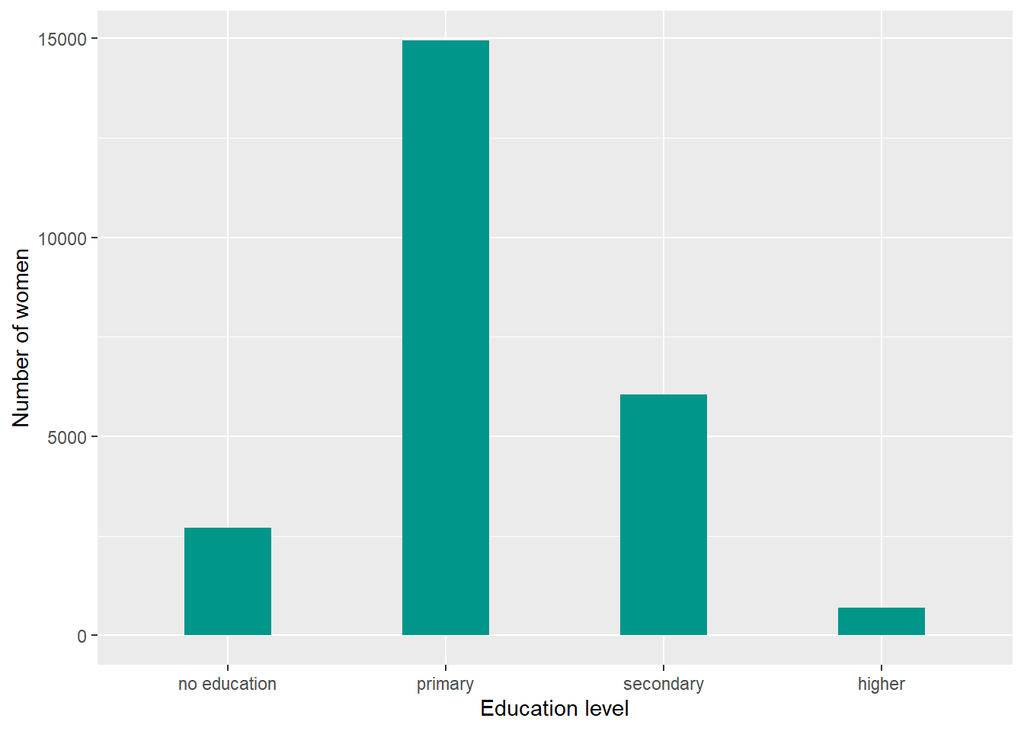

```r
ggplot(analysis_data, aes(x = education_f)) +
  geom_bar(fill = "#00968A", width = .4) +
  labs(x = "Education level", y = "Number of women") #+
```

```r
  # geom_text(
  #   stat = "count",
  #   aes(label = after_stat(count)),
  #   vjust = -0.3
  # )
# +   theme_bw() + theme() + geom_text + scale_y_continuous
```

Incoporate modern contraceptive use:

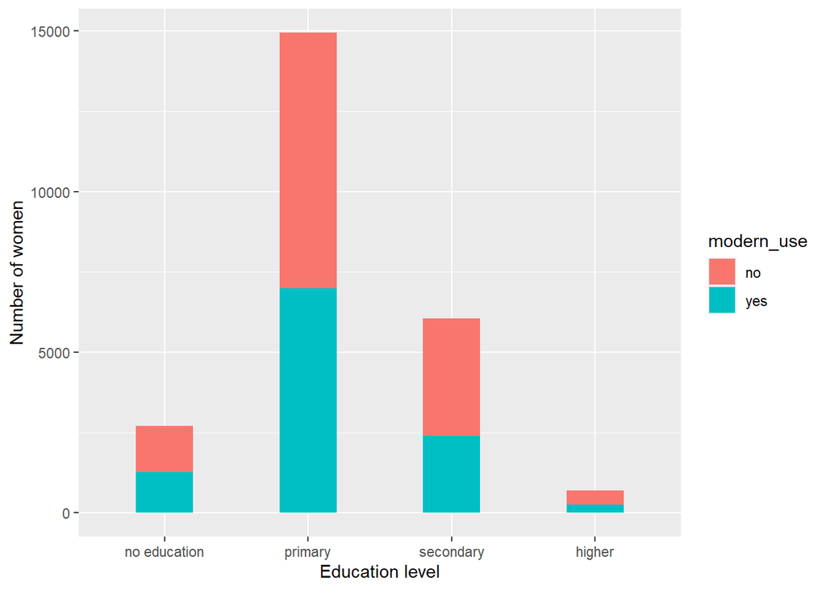

```r
analysis_data %>% group_by(education_f , modern_use) %>% summarise(n=n()) %>%
ggplot(aes(x = education_f, y = n, fill = modern_use)) +
  geom_bar(width = .4, stat = "identity", width = .4) +
  labs(x = "Education level", y = "Number of women") # +
```

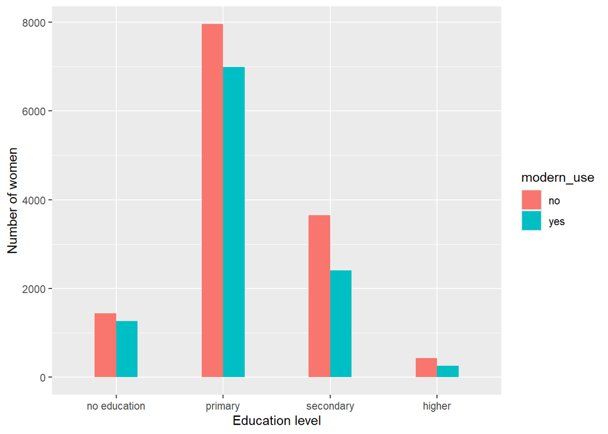

```r
# Or change

analysis_data %>% group_by(education_f , modern_use) %>% summarise(n=n()) %>%
ggplot(aes(x = education_f, y = n, fill = modern_use)) +
  geom_bar(width = .4, stat = "identity", width = .4, position = position_dodge(width = .4)) +
  labs(x = "Education level", y = "Number of women") # +
```

```r
# geom_text(
  #   stat = "count",
  #   aes(label = after_stat(count)),
  #   vjust = -0.3
  # )
# +   theme_bw() + theme() + geom_text + scale_y_continuous
```

## 11.4 Histogram: Distribution of a Number

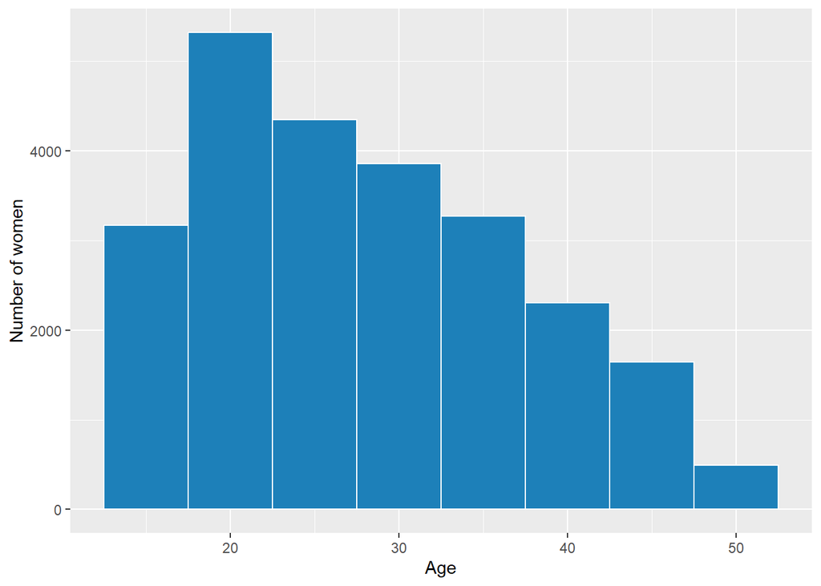

```r
ggplot(analysis_data, aes(x = age)) +
  geom_histogram(binwidth = 5,  fill = "#1D80B9", color = "white") +
  labs(x = "Age", y = "Number of women")
```

Try a few different `binwidth` values to see how it changes the shape.

## 11.5 Scatter Plot: Relationship Between Two Numbers

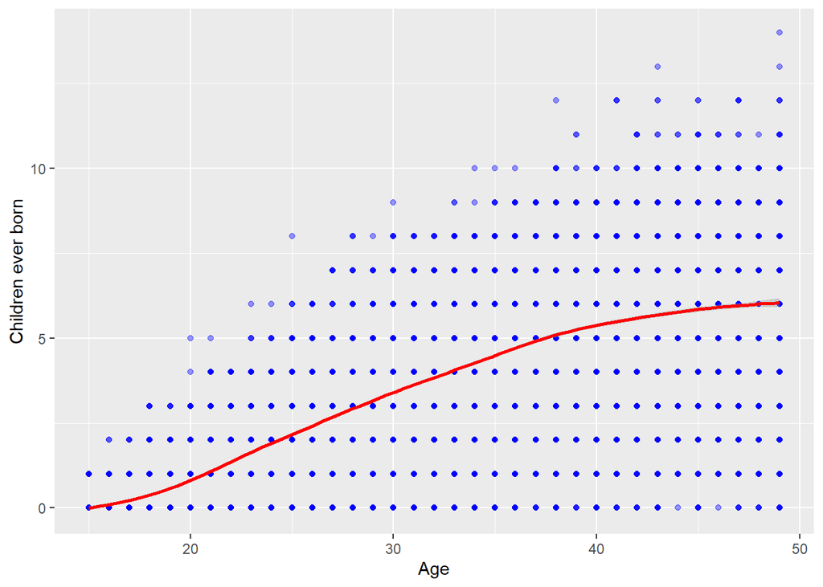

```r
ggplot(analysis_data, aes(x = age, y = children_ever_born)) +
  geom_point(alpha = 0.4, color = "blue") +
  geom_smooth(color = "red")+
  labs(x = "Age", y = "Children ever born")
```

```r
# Let's color by FP use:
# ggplot(analysis_data, aes(x = age, y = children_ever_born)) +
#   geom_point(alpha = 0.4, aes(color = modern_use)) +
#   geom_smooth()+
#   labs(x = "Age", y = "Children ever born")
```

`alpha` adds transparency, which helps when many points overlap.

## 11.6 Extra: Boxplot by Group

In Webinar 1 we used base R’s `boxplot()` to check for outliers in `living_children`. `ggplot2`’s `geom_boxplot()` does the same thing, but makes it easy to compare groups side by side:

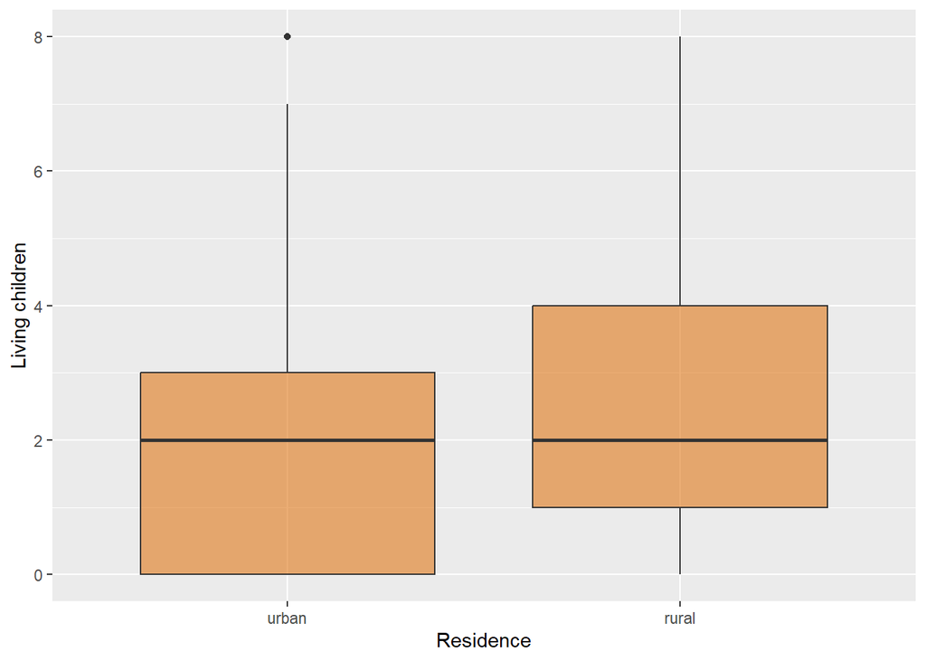

```r
ggplot(analysis_data, aes(x = residence_f, y = living_children)) +
  geom_boxplot(fill = "#E07819", alpha = 0.6) +
  labs(x = "Residence", y = "Living children")
```

#### 11.6.0.1 marital_status Vs age

[figure not shown]

```r
ggplot(analysis_data, aes(x = marital_status, y = age, fill= marital_status)) +
  geom_boxplot( alpha = 0.6) + # or  , show.legend = F
  labs(x = "Residence", y = "Living children")+
  theme(legend.position = "bottom")
```

# 12 Basic Statistical Analysis

## 12.1 Objectives

Participants should be able to:

- Choose between a chi-square test and a t-test for a simple question
- Run and interpret both tests

## 12.2 Choosing a Simple Test

- **Two categorical variables** (e.g., residence vs. modern contraceptive use) -> **chi-square test**
- **One numeric variable across two groups** (e.g., age, urban vs. rural) -> **t-test**

Both return a **p-value**: roughly, the probability of seeing a difference this large if there were truly no difference in the population. A common (if simplistic) rule of thumb is that p < 0.05 suggests the difference is unlikely to be due to chance alone.

## 12.3 Chi-Square Test: Residence and Modern Contraceptive Use

```r
tab <- table(analysis_data$residence_f, analysis_data$modern_use)
tab
```

```
##
##            no   yes
##   urban  3008  2235
##   rural 10475  8685
```

```r
chisq.test(tab)
```

```
##
##  Pearson's Chi-squared test with Yates' continuity correction
##
## data:  tab
## X-squared = 12.034, df = 1, p-value = 0.0005225
```

This tests whether modern contraceptive use is **independent** of place of residence, look at the `p-value` in the output.

## 12.4 T-Test: Age by Residence

```r
t.test(age ~ residence_f, data = analysis_data)
```

```
##
##  Welch Two Sample t-test
##
## data:  age by residence_f
## t = -3.8776, df = 8734.5, p-value = 0.0001063
## alternative hypothesis: true difference in means between group urban and group rural is not equal to 0
## 95 percent confidence interval:
##  -0.8089588 -0.2656879
## sample estimates:
## mean in group urban mean in group rural
##            27.61320            28.15052
```

This compares the **mean age** of urban vs. rural women. The output includes the mean in each group, a confidence interval for the difference, and a p-value. `t.test()` with this formula syntax requires the grouping variable to have exactly two levels, which `residence_f` does (Urban/Rural).

# 13 Customizing and Saving Charts

## 13.1 Objectives

Participants should be able to:

- Add titles, axis labels, and themes to a `ggplot2` chart
- Save a chart as a high-resolution image file

## 13.2 Titles, Labels, and Themes

- `labs()` – add a title, subtitle, axis labels, and caption
- `theme_minimal()`, `theme_classic()`, `theme_bw()` quick built-in style presets
- `theme()` fine-grained control (font sizes, legend position, etc.)

A well-labeled chart should be understandable without needing to read the surrounding report text.

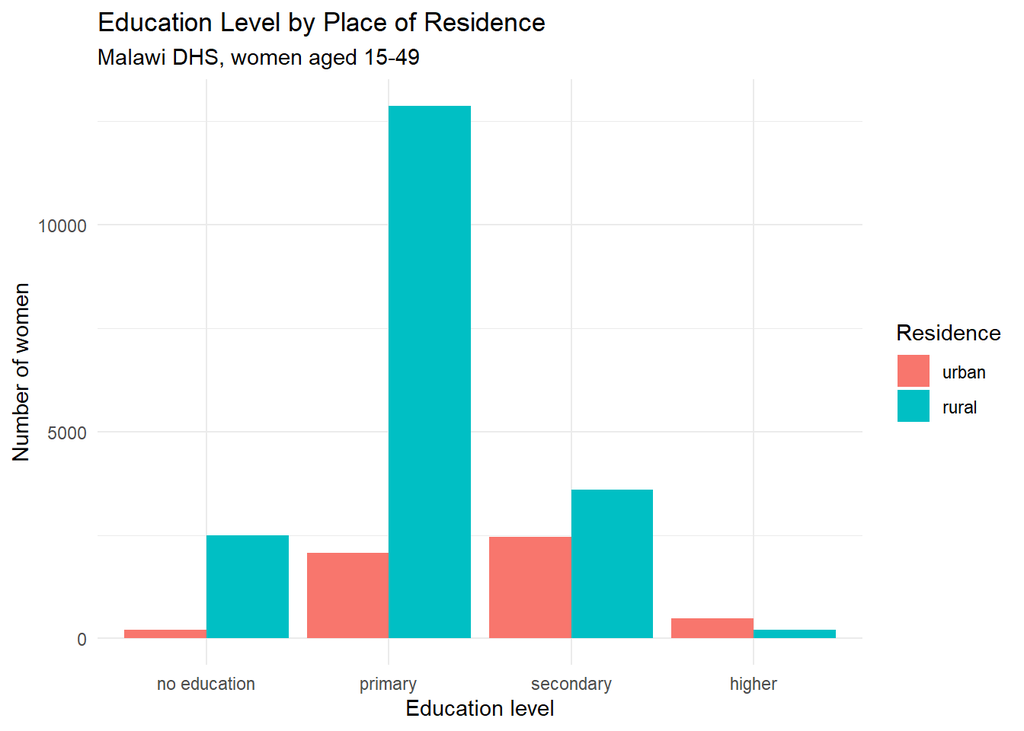

```r
p <- ggplot(analysis_data, aes(x = education_f, fill = residence_f)) +
  geom_bar(position = "dodge") +
  labs(
    title    = "Education Level by Place of Residence",
    subtitle = "Malawi DHS, women aged 15-49",
    x        = "Education level",
    y        = "Number of women",
    fill     = "Residence"
  ) +
  theme_minimal()

p
```

## 13.3 Saving a Chart with `ggsave()`

```r
ggsave("output/education_by_residence.png",
       plot = p, width = 7, height = 5, dpi = 300)
```

`ggsave()` picks the file format from the extension you give it (`.png`, `.pdf`, `.jpg`, …), and by default saves the *last* plot displayed if you don’t pass `plot =`.

# 14 Exporting Results and Reproducible Workflow

## 14.1 Objectives

Participants should be able to:

- Export a summary table to `.csv`
- Organize a project so the whole analysis can be re-run from scratch

## 14.2 Exporting Result Tables

```r
summary_table <- analysis_data %>%
  group_by(residence_f, education_f) %>%
  summarise(
    women          = n(),
    mean_age       = mean(age, na.rm = TRUE),
    modern_use_pct = mean(modern_use, na.rm = TRUE) * 100,
    .groups = "drop"
  )

write_csv(summary_table, "output/summary_by_residence_education.csv")
```

## 14.3 Organizing a Reproducible Project

A reproducible workflow means anyone (including future you) can re-run your script from top to bottom and get the exact same results:

```
R_Training/
|
|-- data/
|   |-- DHS_data.dta
|   `-- analysis_data_clean.rds
|
|-- scripts/
|   |-- Workshop1_DHS_DataCleaning.Rmd
|
|
`-- output/
    |-- summary_by_residence_education.csv
    `-- education_by_residence.png
```

- Keep raw data, scripts, and outputs in separate, clearly named folders
- Never edit raw data files by hand – only through your script
- Write scripts to run top-to-bottom without manual steps in between
- Export every result you’ll need again as its own file

# 15 Practical Exercise

Using `analysis_data`:

1. Group by `education_f` and compute the number of women and the mean number of living children in each group.
2. Create a wide table of `age_group_f` by `residence_f` counts, then convert it back to long format.
3. Build a histogram of `wealth_quintile`.
4. Build a bar chart of `marital_status`, with bars filled by `residence_f`.
5. Run a chi-square test of `education_f` against `modern_use`.
6. Run a t-test comparing `age` between women with and without media exposure (`media_exposure`).
7. Add a title, axis labels, and a theme to one of your charts, then save it with `ggsave()`.
8. Export your Step 1 summary table to `output/` as a `.csv` file.

# 16 Key Takeaways

By the end of this practical, participants should be able to:

- Reload a cleaned dataset instead of repeating the cleaning pipeline
- Group and summarize data with `group_by()` and `summarise()`
- Reshape data between long and wide formats
- Build and interpret bar charts, histograms, scatter plots, and boxplots with `ggplot2`
- Run and interpret a chi-square test and a t-test
- Customize and save publication-ready charts
- Export result tables and organize a reproducible project